# EDA_Top_50_US_Tech_Companies

## **Top 50 US Tech Companies 2022-2023**

Exploratory Data Analysis of the Top 50 US Technology Companies of the 2022-2023 fiscal year.

Questions answered through this analysis.

- Which state has the most tech companies on the list?
- Sector with the most companies among the list?
- Which companies brought in the most revenue?
- Which companies are the most valuable on the market.

## **Data source**

Datahub.io

### **Data Description**

Company Name - Name of company.

Industry- Industry that the company belongs to.

Sector- Sector that the company belongs to.

HQ State- State where the company's headquarters are.

Founding Year - The year the company was founded.

Annual Revenue 2022-2023(USD in Billions)- Revenue of the company in the 2022-2023 fiscal year.

Market Cap(USD in Trillions) - Market Cap of the company.

Stock Name- Company's stock name.

Annual Income tax in 2022-2023 - Annual Income tax of the company.

Employee Size- number of employees in the company.

#### **Importing necessary libraries.**

```python
#Libraries to help with reading and manipulating data
import pandas as pd
import numpy as np
```

```python
#Libraries to help with data visualization
import matplotlib.pyplot as plt
import seaborn as sns
```

```python
#restricting the float value to 3 decimal places
pd.set_option('display.float_format',lambda x:'%.3f' % x)
```

```python
#Access to google drive
from google.colab import drive
drive.mount('/content/drive')
```

#### **Importing Dataset**

```python
data=pd.read_csv('/content/drive/MyDrive/Top 50 US Tech Companies 2022 - 2023.csv')
```

#### **Understanding and cleaning data**

**First and last 5 rows of the dataset**

```python
#first 5 rows
data.head()
```

|  | Company Name | Industry | Sector | HQ State | Founding Year | Annual Revenue 2022-2023 (USD in Billions) | Market Cap (USD in Trillions) | Stock Name | Annual Income Tax in 2022-2023 (USD in Billions) | Employee Size |
| --- | --- | --- | --- | --- | --- | --- | --- | --- | --- | --- |
| 0 | Apple Inc. | Technology | Consumer Electronics | California | 1905 | 387.530 | 2.520 | AAPL | 18.314 | 164000 |
| 1 | Microsoft Corporation | Technology | Software Infrastructure | Washington | 1905 | 204.090 | 2.037 | MSFT | 15.139 | 221000 |
| 2 | Alphabet (Google) | Technology | Software Infrastructure | California | 1905 | 282.830 | 1.350 | GOOG | 11.356 | 190234 |
| 3 | Amazon | Technology | Software Application | Washington | 1905 | 513.980 | 1.030 | AMZN | -3.217 | 1541000 |
| 4 | NVIDIA Corporation | Technology | Semiconductors | California | 1905 | 26.970 | 0.653 | NVDA | 0.189 | 22473 |

```python
#Last 5 rows of the dataset
data.tail()
```

|  | Company Name | Industry | Sector | HQ State | Founding Year | Annual Revenue 2022-2023 (USD in Billions) | Market Cap (USD in Trillions) | Stock Name | Annual Income Tax in 2022-2023 (USD in Billions) | Employee Size |
| --- | --- | --- | --- | --- | --- | --- | --- | --- | --- | --- |
| 45 | GlobalFoundries | Technology | Semiconductors | New York | 1905 | 8.100 | 0.038 | GFS | 0.086 | 14600 |
| 46 | IQVIA Holdings | Technology | Software Application | North Carolina | 1905 | 14.410 | 0.037 | IQV | 0.260 | 85000 |
| 47 | Marvell Technology Inc. | Technology | Semiconductors | California | 1905 | 5.910 | 0.035 | MRVL | 0.249 | 6695 |
| 48 | Dell Technologies Inc. | Technology | Computer Hardware | Texas | 1905 | 102.300 | 0.028 | DELL | 0.981 | 133000 |
| 49 | HP Inc. | Technology | Computer Hardware | California | 1905 | 59.780 | 0.028 | HPQ | 1.238 | 51000 |

**Checking for missing values in the data**

```python
data.isnull().sum()
```

```
Company Name                                        0
Industry                                            0
Sector                                              0
HQ State                                            0
Founding Year                                       0
Annual Revenue 2022-2023 (USD in Billions)          0
Market Cap (USD in Trillions)                       0
Stock Name                                          0
Annual Income Tax in 2022-2023 (USD in Billions)    0
Employee Size                                       0
dtype: int64
```

- Data set has no missing values.

**Checking for duplicated values**

```python
data.duplicated().sum()
```

```
0
```

**Understanding shape of dataset**

```python
#shape of dataset
print('there are', data.shape[0],'rows and',data.shape[1],'columns.')
```

```
there are 50 rows and 10 columns.
```

**Checking data types of the columns for the dataset**

```python
data.info()
```

```
<class 'pandas.core.frame.DataFrame'>
RangeIndex: 50 entries, 0 to 49
Data columns (total 10 columns):
 #   Column                                            Non-Null Count  Dtype
---  ------                                            --------------  -----
 0   Company Name                                      50 non-null     object
 1   Industry                                          50 non-null     object
 2   Sector                                            50 non-null     object
 3   HQ State                                          50 non-null     object
 4   Founding Year                                     50 non-null     int64
 5   Annual Revenue 2022-2023 (USD in Billions)        50 non-null     float64
 6   Market Cap (USD in Trillions)                     50 non-null     float64
 7   Stock Name                                        50 non-null     object
 8   Annual Income Tax in 2022-2023 (USD in Billions)  50 non-null     float64
 9   Employee Size                                     50 non-null     int64
dtypes: float64(3), int64(2), object(5)
memory usage: 4.0+ KB
```

- There are 5 numerical columns in the data and 5 object type columns.

**Checking the statistical summary of the data.**

```python
data.describe().T
```

|  | count | mean | std | min | 25% | 50% | 75% | max |
| --- | --- | --- | --- | --- | --- | --- | --- | --- |
| Founding Year | 50.000 | 1905.000 | 0.000 | 1905.000 | 1905.000 | 1905.000 | 1905.000 | 1905.000 |
| Annual Revenue 2022-2023 (USD in Billions) | 50.000 | 51.204 | 97.413 | 2.060 | 7.652 | 17.665 | 40.815 | 513.980 |
| Market Cap (USD in Trillions) | 50.000 | 0.252 | 0.490 | 0.028 | 0.051 | 0.082 | 0.160 | 2.520 |
| Annual Income Tax in 2022-2023 (USD in Billions) | 50.000 | 1.387 | 3.688 | -3.217 | 0.099 | 0.280 | 0.945 | 18.314 |
| Employee Size | 50.000 | 83249.620 | 220586.929 | 2993.000 | 14150.000 | 24725.000 | 70155.750 | 1541000.000 |

- All companies where founded in the same year of 1905 as the **Founding year column** has a **std is 0.**
- The **Annual Revenue column** has an outlier as there is a high **std of 97.413** and the **max is 513.980** whilst the **mean is 51.204**
- The **Employee Size** column data is skewed as its **std of 220586.929** is **higher than the mean of 83249.62** and it has a large **max of 1541000.**

**Dropping Unnecessary columns**

```python
#all columns.
data.columns
```

```
Index(['Company Name', 'Industry', 'Sector', 'HQ State', 'Founding Year',
       'Annual Revenue 2022-2023 (USD in Billions)',
       'Market Cap (USD in Trillions)', 'Stock Name',
       'Annual Income Tax in 2022-2023 (USD in Billions)', 'Employee Size'],
      dtype='object')
```

```python
#Dropping unnecessary columns
data.drop(['Industry','Founding Year','Stock Name'],axis=1,inplace=True)
```

```python
#Checking unique values in the HQ State column
print ('There are',data['HQ State'].nunique(), 'different states in the dataset.')
```

```
There are 13 different states in the dataset.
```

```python
#Checking unique values in the Sector column
print('There are', data['Sector'].nunique(),'different sectors in the dataset.')
```

```
There are 8 different sectors in the dataset.
```

### **Univariate analysis**

```python
data['HQ State'].value_counts()
```

```
California        33
Texas              4
Washington         2
New York           2
Connecticut        1
Massachusetts      1
New Jersey         1
Wisconsin          1
Idaho              1
Montana            1
Florida            1
Arizona            1
North Carolina     1
Name: HQ State, dtype: int64
```

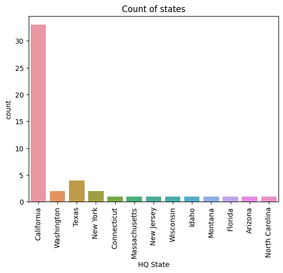

```python
sns.countplot(data=data,x='HQ State')
plt.xticks(rotation=90)
plt.title('Count of states')
plt.show()
```

- 33 companies have their companies their headquarters in California which makes it the top state.

```python
data['Sector'].value_counts()
```

```
Software Application        15
Semiconductors              14
Software Infrastructure     12
IT Services                  3
Computer Hardware            3
Consumer Electronics         1
Communication Equipments     1
Electronic Components        1
Name: Sector, dtype: int64
```

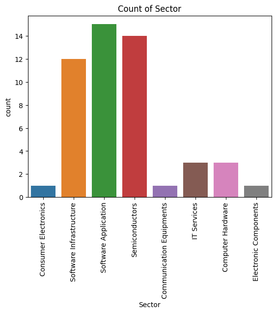

```python
sns.countplot(data=data, x='Sector')
plt.xticks(rotation=90)
plt.title('Count of Sector')
plt.show()
```

- Software Application sector has the most companies on the list with a total of 15 companies.

### **Bivariate Analysis**

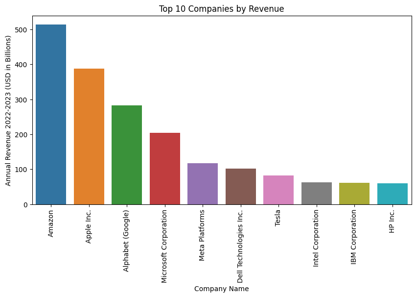

```python
plt.figure(figsize= (10,5))
top=data.groupby(['Company Name'],as_index=False)['Annual Revenue 2022-2023 (USD in Billions)'].sum().sort_values(by='Annual Revenue 2022-2023 (USD in Billions)', ascending =False).head(10)
sns.barplot(data=top,x= 'Company Name', y='Annual Revenue 2022-2023 (USD in Billions)')
plt.title('Top 10 Companies by Revenue')
plt.xticks(rotation=90)
plt.show()
```

- Amazon brought in the most revenue in the 2022-2023 fiscal year.

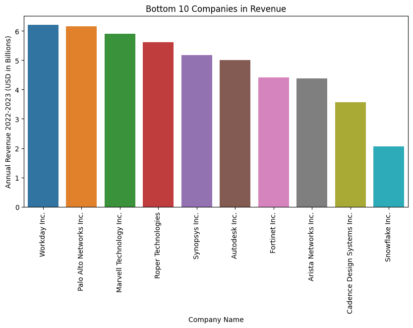

```python
plt.figure(figsize=(10,5))
low=data.groupby(['Company Name'],as_index=False)['Annual Revenue 2022-2023 (USD in Billions)'].sum().sort_values(by='Annual Revenue 2022-2023 (USD in Billions)', ascending=False).tail(10)
sns.barplot(data=low,x='Company Name', y='Annual Revenue 2022-2023 (USD in Billions)')
plt.title('Bottom 10 Companies in Revenue')
plt.xticks(rotation=90)
plt.show()
```

- Snowflake Inc made the least revenue among the top 50 in the 2022-2023 fiscal year.

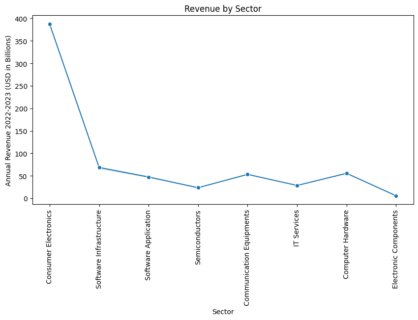

```python
plt.figure(figsize=(10,5))
sns.lineplot(data=data,x='Sector',y='Annual Revenue 2022-2023 (USD in Billions)', marker='o',errorbar=('ci',False))
plt.title('Revenue by Sector')
plt.xticks(rotation=90)
plt.show()
```

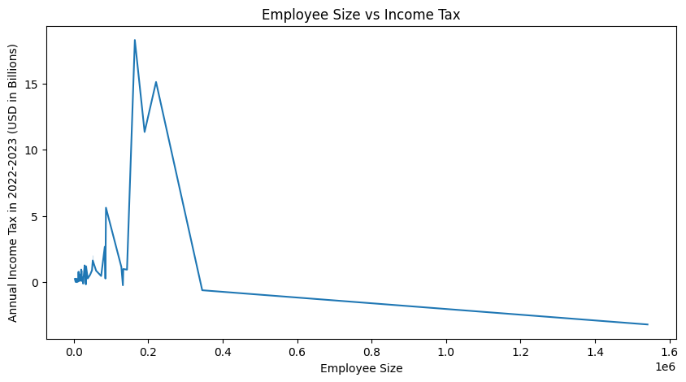

```python
plt.figure(figsize=(10,5))
sns.lineplot(data=data, x='Employee Size', y='Annual Income Tax in 2022-2023 (USD in Billions)')
plt.title('Employee Size vs Income Tax')
plt.show()
```

```python
#Correlation between Employee size and Annual Income Tax
data[['Employee Size','Annual Income Tax in 2022-2023 (USD in Billions)']].corr()
```

|  | Employee Size | Annual Income Tax in 2022-2023 (USD in Billions) |
| --- | --- | --- |
| Employee Size | 1.000 | -0.019 |
| Annual Income Tax in 2022-2023 (USD in Billions) | -0.019 | 1.000 |

- the negative correlation is closer to 0 meaning that Employee Size and Annual Income tax barely have a relationship.

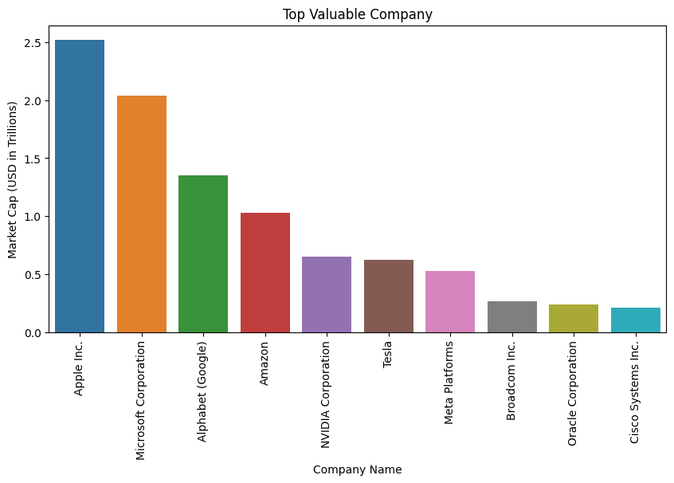

```python
plt.figure(figsize=(10,5))
value=data.groupby(['Company Name'],as_index=False)['Market Cap (USD in Trillions)'].sum().sort_values(by='Market Cap (USD in Trillions)',ascending=False).head(10)
sns.barplot(data=value,x='Company Name', y='Market Cap (USD in Trillions)')
plt.title('Top Valuable Company')
plt.xticks(rotation=90)
plt.show()
```

Apple Inc has the highest Market Cap, meaning it is the highest valued company on the stock market among the top 50 list of companies.